# France’s Finest Wines: An examination of the best reviewed wines originating from France - (Stat 311 Final Project)

Ali Basbeth, Joncarlo Abarcar, Max Jayne

2022-03-13

## Section 1 - Introduction

Liquor has long been a recreational pleasure for humans, and we have spent countless hours as a species cultivating and refining practices of distillation and fermentation to create better tasting and more effective alcoholic concoctions. Wine is one of the most famous types of Liquor in the world, and the cost of wine has been increasing every year as the demand for wine goes up while the cost to make it increases. “Inflation in the US was 8 percent over the period 2014 to (2019), according to the US Bureau of Labor Statistics” (Kavanagh 2019) The average cost of a single wine bottle increased about $13 over those 5 years. With how much wine is shipped around the world, the demand for wine continues to grow. The COVID-19 pandemic has only amplified the rate of inflation as supply chain shortages have only made production slow down and costs increase. All of this culminates with a massive $420 billion dollar global industry surrounding wine production and it’s import and export around the world.

Over hundreds of years, there are millions of varieties of wines that have been created and produced, and among these, are varieties selected by wine tasters and appraisers and treated like famous works of art before being happily consumed. But how do these wines get this amazing acclaim? What determines whether a wine is ‘good’ or ‘great’? Is it the price? Variety? Origin? We examine these questions and explore how wines are rated in this analysis.

Wine is one of the most popular beverages in the world. We argue that it is important for us to understand what might influence reviews regarding wine. One study found that “changes in the stated price of a sampled wine influenced not only how good volunteers thought it tasted, but the activity of a brain region that is involved in our experience of pleasure” (CalTech, 2008). Building on this statement, we want to test this hypothesis whether it is appropriate to say that ratings on wine are affected by their price range. Moreover, we will add other possible explanatory variables such as regions. For instance, the French region of Bordeaux is known for producing high quality wine, as mentioned by Morais (2017), “Bordeaux is considered to be the largest fine-wine region on earth”. Therefore, we are interested in finding out which region produces the best wine. Other explanatory variables will be the different varieties of wine grapes; these include, red wine, white wine, riesling, rosé, sparkling, and fortified wines (Masterclass 2021), as well as wine description length as robust descriptions tend to appeal more to consumers.

We have determined the potential response or outcome variable within the Wine Reviews dataset as points. The points measure indicates the number of points WineEnthusiast users rated the wine at on a scale of 1-100 and attempts to provide an overall rating of the wine. As the initial dataset contained 130,000 wines and their associated reviews, we have filtered the data in our dataset to exclusively examine wines that originate in France as a leading global wine producer. Additionally, we removed any rows that had an NA value in any of the relevant variables of interest, leaving us with around 17,000 wines and associated reviews.

We have recoded multiple explanatory variables as follows:

- We have created a new numerical variable log_price which takes the data from price and applied a log base 10 function. This is to provide better comparison between prices.
- A new categorical variable called “expensive10_winery” is the results of the recoding of the winery variables. Since there are a total of more than 2000 wineries, I decided to average them by their mean of price, which top 10 wineries produces the most expensive wine. The value that this variable takes is “yes” for top 10 wineries that is the most expensive, and “no” for the rest of the data.
- Similarly the new categorical variable “expensive10_region” where I average the mean of price on the previously region_1 variable, and re coded it to top 10 regions that produce the most expensive wine.
- A new categorical variable Rose was added determining if the wine is of the rose grape variety. Variety can affect cost of wine, taste, smell and most important, reviews.
- A new categorical variable Alsace was added determining if the wine’s primary region is Alsace. Region also has a strong effect on the taste and smell of grapes and wines and therefore the reviews.
- We have taken the description variable and summed the total number of characters present as a numeric variable entitled desc_char_count. The theory would be that wines with robust descriptions will have the best rating, wines with descriptions that are too long or too short may have affected ratings.
- From the previous numeric variable, we have created a new categorical variable examing description length entitled long_desc which categorizes each instance of a description as long if it contains more than 250 characters and short otherwise. About 32% of the listed wines have a description categorized as long.
- A new variable was recoded from the province variable named province_NS. This variable categorizes the province categories by their geogrpahical location in the north or south of France. The notable wine provinces in Northern France are Alsace, Burgundy, Champagne, and the Loire Valley. All other provinces are located in the southern half of the country. (Note: France other was categorized with Southern France due to more existing territories in Southern France such as Savoie, Malbec, and Jura provinces not included in the original province category, thus this category is presumed to be derived from smaller Southern provinces).

**Data Citation**

The dataset used for this analysis, entitled *Wine Reviews: 130k wine reviews with variety, location, winery, price, and description*, is hosted publicly on Kaggle by Zackthoutt, published five years ago on June 21st, 2017 and last updated four years ago on November 27th of 2017. The dataset can be found at https://www.kaggle.com/zynicide/wine-reviews. The data used in the dataset is pulled from WineMag’s rating system: https://www.winemag.com/ratings/. (The APA citation can be found in the bibliography). The data was collected through taking reviews from a wine magazine called Wine Enthusiast during the week of June 15th, 2017 & the week of November 22nd, 2017. The reviews are submitted by various wine tasters from across the world. A brief summary of the variables in the dataset can be found below.

| No | Variables | Type | Description |
| --- | --- | --- | --- |
| 1 | Country | Character | The country where the wine is from(country of origin) |
| 2 | description | Character | The description of the wine’s taste, smell, look, feel, etc |
| 3 | designation | Character | The vineyard within the winery where the grapes that made the wine are from |
| 4 | points | Numerical | WineEnthusiast’s rating of the wine on a scale from 1-100 |
| 5 | price | Numerical | The cost of for a bottle of wine |
| 6 | province | Categorical | Province or state the wine is from |
| 7 | region1 | Categorical | The wine growing area in a province or state(i.e Napa) |
| 8 | region 2 | Categorical | More specific regions specified within a wine growing area (ie Rutherford inside the Napa Valley), but this value can sometimes be blank |
| 9 | taster_name | Categorical | Taster Name |
| 10 | taster_twitter_handle | Categorical | Taster’s Twitter handle |
| 11 | Title | Categorical | The title of the wine review |
| 12 | variety | Categorical | The type of grapes used to make the wine (ie Pinot Noir) |
| 13 | winery | Categorical | The Winery that produced the wine |
| 14 | desc_char_count | Numerical (recoded) | The total number of characters in the description variable |
| 15 | log_price | Numerical (recoded) | Wine price with log base 10 function applied |
| 16 | province_NS | Categorical (recoded) | Whether the wine originated from a province in the north or south of France |
| 17 | expensive10_winery | Categorical (recoded) | Whether the wine came from one of the top 10 most expensive wineries in France |
| 18 | expensive10_region | Categorical (recoded) | Whether the wine came from one of the top 10 most expensive wine regions in France |
| 19 | Rose | Categorical (recoded) | Whether the wine is of the variety Rose or not |
| 20 | Alsace | Categorical (recoded) | Whether the wine is from the Alsace region or not |
| 21 | long_desc | Categorical (recoded) | Whether the wine description contains more than 250 characters or not |

## Section 2 - Model Building

### Model proposed by Ali:

After conducting in-depth analysis on the data to determine the best possible explanatory variables, I have decided to choose three explanatory variables. The first one that I used is log10 of price. The second variable that I use is called “expensive10_winery” and “expensive10_region”. The model that I chose for the response variable of “points” is explained by the three variables that I talked about above.

My thought process in creating this model is that first of all, the data set is large, and it is very challenging for me to create a model. In addition, the x categorical variables in the data set have more than just two or three levels. With this in mind, I decided to just choose 10 wineries from the variable “winery” that has the most expensive average price of the wine that they produce, with values “yes”, and “no”. Furthermore, I have a little bit of background knowledge regarding wine, since I am a documentary lover, and I watch a lot of interesting documentaries. I have watched several of them that are related to wine. In particular, I am a Geography major, and I am personally interested in the spatial distribution of wine. Therefore, I decided to choose the variable “region” which is where the wine is produced in France. For each province, there are several regions. After doing some analysis on the data, I have found that it is appropriate to only choose the top 10 most regions that produced the most expensive wine.

```
## # A tibble: 10 x 2
##    winery                         mean_price
##    <chr>                               <dbl>
##  1 ChÃ¢teau les Ormes Sorbet           3300
##  2 ChÃ¢teau PÃ©trus                    2250
##  3 Domaine du Comte Liger-Belair       1489.
##  4 ChÃ¢teau Cheval Blanc                825
##  5 ChÃ¢teau d'Yquem                     800
##  6 ChÃ¢teau Laville Haut-Brion          580
##  7 ChÃ¢teau Haut-Brion                  572.
##  8 ChÃ¢teau La Mission Haut-Brion       546.
##  9 ChÃ¢teau Ausone                      507.
## 10 ChÃ¢teau Mouton Rothschild           479.
```

```
## # A tibble: 10 x 2
##    region_1                      mean_price
##    <chr>                              <dbl>
##  1 La RomanÃ©e                        1875
##  2 Musigny                             742.
##  3 Montrachet                          616.
##  4 RomanÃ©e-St.-Vivant                 501.
##  5 Mazoyeres-Chambertin                475
##  6 Chevalier-Montrachet                471.
##  7 Bonnes-Mares                        464.
##  8 Bienvenues BÃ¢tard-Montrachet       443
##  9 Chambertin Clos de BÃ¨ze            433.
## 10 BÃ¢tard-Montrachet                  391.
```

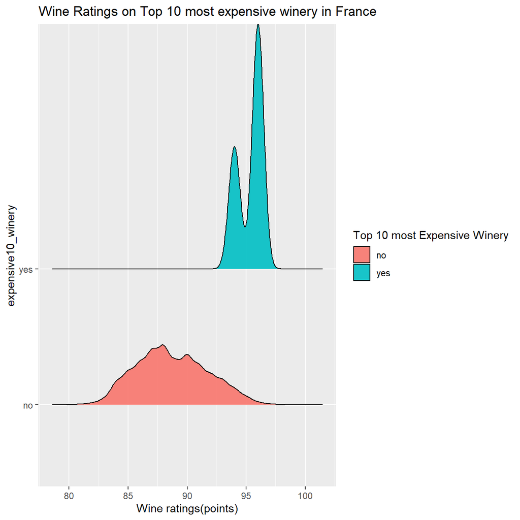

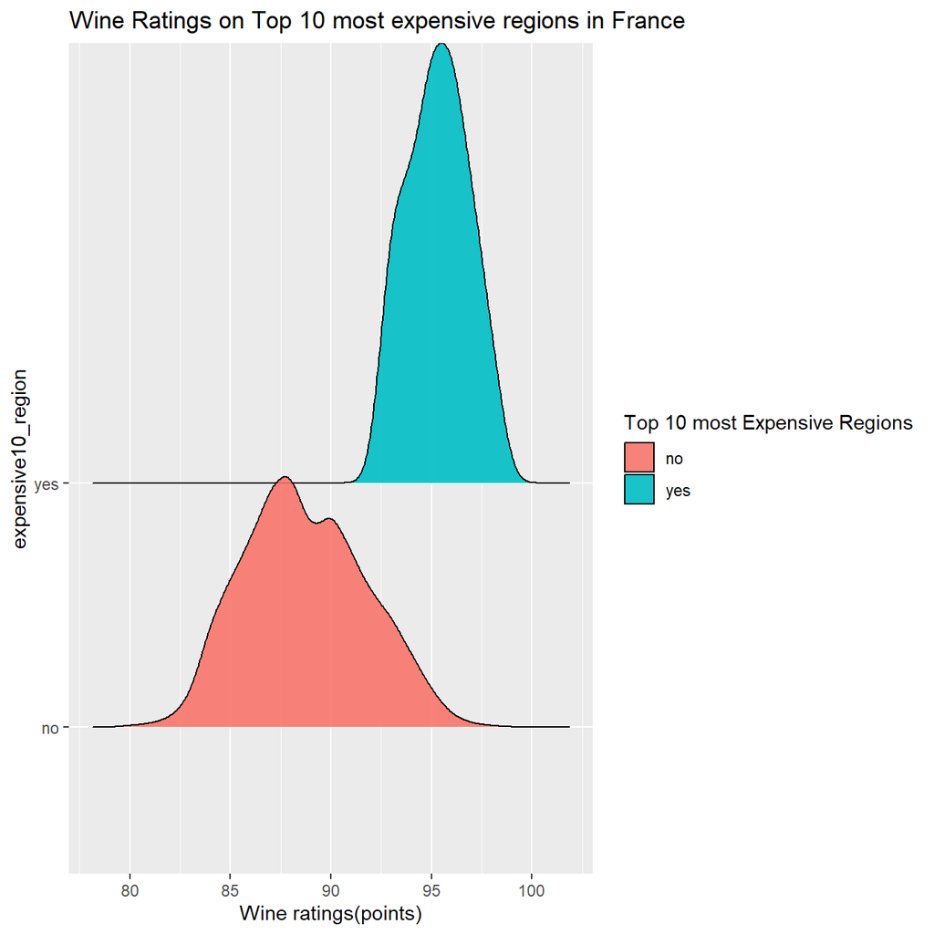

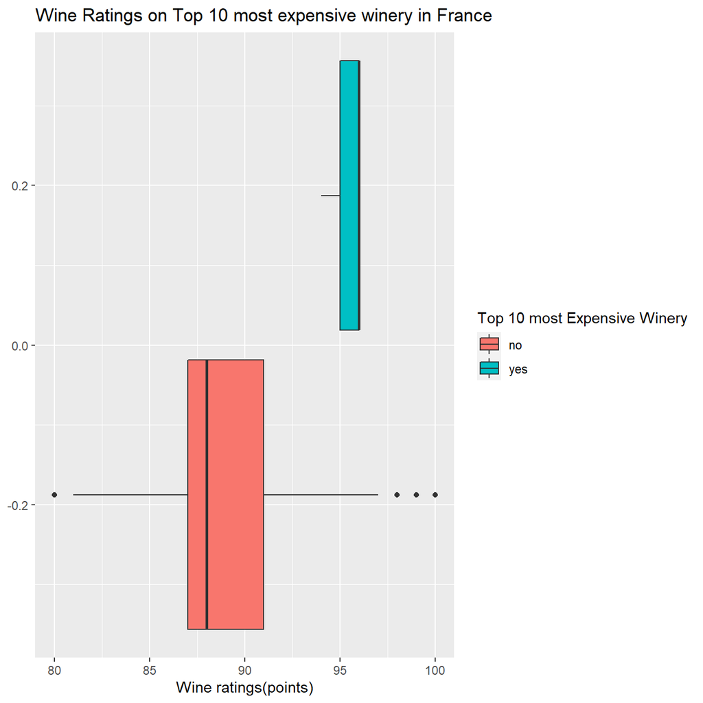

```
## # A tibble: 2 x 3
##   expensive10_winery median   IQR
##   <chr>               <int> <dbl>
## 1 no                     88     4
## 2 yes                    96     1
```

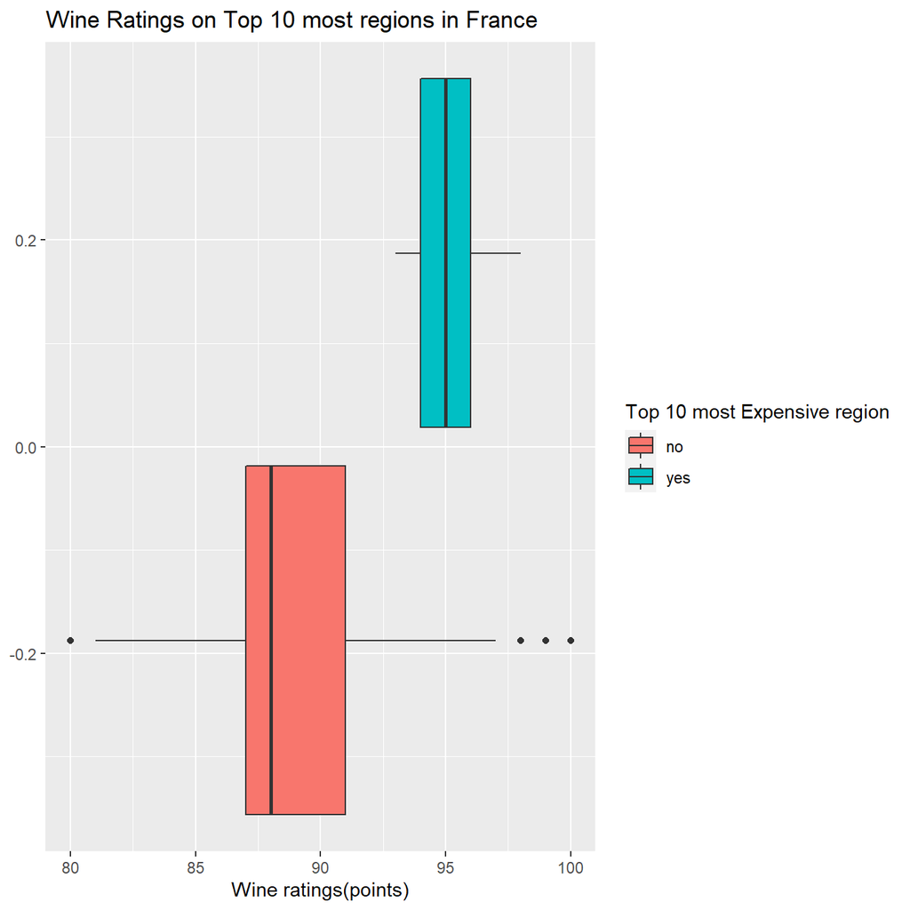

```
## # A tibble: 2 x 3
##   expensive10_region median   IQR
##   <chr>               <int> <dbl>
## 1 no                     88     4
## 2 yes                    95     2
```

```
## # A tibble: 4 x 2
##   term                  estimate
##   <chr>                    <dbl>
## 1 (Intercept)              79.3
## 2 log10(price)              6.53
## 3 expensive10_wineryyes    -5.15
## 4 expensive10_regionyes    -1.60
```

```
## # A tibble: 1 x 2
##   r.squared adj.r.squared
##       <dbl>         <dbl>
## 1     0.464         0.464
```

```
## # A tibble: 1 x 3
##   .metric .estimator .estimate
##   <chr>   <chr>          <dbl>
## 1 rmse    standard        2.22
```

```
##   min max
## 1  80 100
```

### Model Proposed by Joncarlo:

```
## # A tibble: 4 x 2
##   term        estimate
##   <chr>          <dbl>
## 1 (Intercept)  79.2
## 2 log_price     6.48
## 3 Roséyes       0.0115
## 4 Alsaceyes     1.23
```

```
## # A tibble: 1 x 2
##   r.squared adj.r.squared
##       <dbl>         <dbl>
## 1     0.478         0.478
```

```
##    prediction points
## 1    89.70554     87
## 2    90.00221     87
## 3    90.62446     86
## 4    88.13983     86
## 5    86.81640     86
## 6    85.94307     86
## 7    87.32978     88
## 8    87.64751     91
## 9    88.40288     91
## 10   88.86050     91
```

```
## # A tibble: 1 x 3
##   .metric .estimator .estimate
##   <chr>   <chr>          <dbl>
## 1 rmse    standard        2.18
```

```
## [1] 20
```

This model looks at three variables which all play a part in what determines the ratings of wine out of 100 points: Price or cost of the wine, variety of grape that the wine is made from, and the region of France that the wine was produced. Specifically in this model, we are looking at how the grape variety Rosé and the region of Alsace affects the points rating of the wine. These specific types of variety and region was chosen due to how common they showed up in France’s wine. With the grapes being the base/start of the process of making wine, it is the first initial cost of producing the product. The certain type of variety can affect cost of wine, taste, and smell before the wine even starts to get produced, all aspects that reviews look at to determine their points. Region is an interesting variable to look at because when it comes to produce, people like to say that when it is grown in certain areas/regions that it comes out better. This means we can look at wine where their grape variety could Rosé, but it was produced in two different regions which may create a difference in points. With an adjusted r-squared value of 0.47, this model can relatively predict the data accurately.

Looking at the fit model for this main effects equation, you can see that Rosé does not have a big effect on the slope as it is only multiplied by a miniscule value. This means that whether the variety of grape is Rosé or not, it does not have a big correlation to the overall rating of the wine. But looking at the region of Alsace, it has a bit more of an effect on the rating as it is being multiplied by more than 1, thus increasing the slope more.

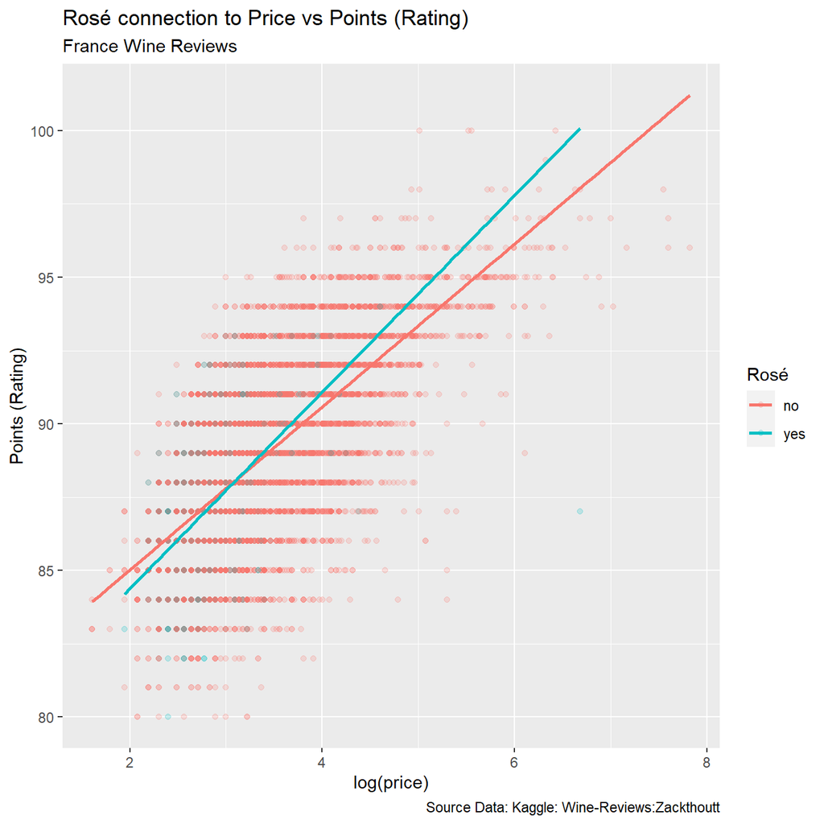

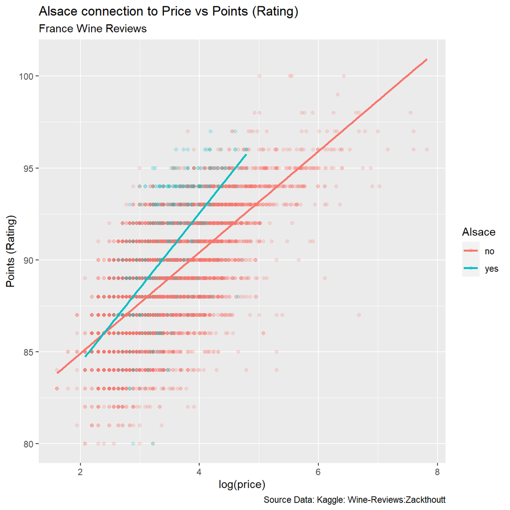

To take a closer look at how the Alsace and Rosé effects the ratings of the wines, we made 2 scatterplots of the ratings and price, but fitted lines that represent whether the variable was present in the wine or not. First thing to notice about both of these plots is that both of these variables do not have data in the higher brackets of costs of wine which may be a big reason why these are some of the most common region and variety. When comparing the two scatterplots, you can see that both of these variables positively increase the slope, but Alsace just multiplies the slope at a higher value. This proves that these variables are correlated to overall rating of the wine, but the region plays a bigger role than the variety.

### Model Proposed by Max:

```
## # A tibble: 4 x 2
##   term             estimate
##   <chr>               <dbl>
## 1 (Intercept)       77.1
## 2 log_price          5.17
## 3 desc_char_count    0.0182
## 4 province_NSsouth  -0.115
```

```
## # A tibble: 1 x 2
##   r.squared adj.r.squared
##       <dbl>         <dbl>
## 1     0.597         0.597
```

```
##    prediction points
## 1    87.41439     87
## 2    87.99651     87
## 3    89.18526     86
## 4    87.82305     86
## 5    85.89489     86
## 6    86.19378     86
## 7    87.44476     88
## 8    88.88436     91
## 9    89.12272     91
## 10   89.77857     91
```

```
## # A tibble: 1 x 3
##   .metric .estimator .estimate
##   <chr>   <chr>          <dbl>
## 1 rmse    standard        1.94
```

```
## [1] 20
```

$$\hat{points} = 77.1 + 5.17 * log\_price + 0.0182 * desc\_char\_count - 0.115 * province\_NSsouth$$

This model examines three variables to determine wine rating out of 100 (points): Price, total number of characters in the description, and province of origin. High quality wines, or those with the best reviews, tend to be those that have a sense of luxury associated with them. Aspects such as higher prices, long and robust descriptions, and a rich cultural/geographic history can all be used to guage wine quality, and therefore we attempt to use them to predict reviews.

While our capitalist society naturally attempts to link price and quality, our assumption that reviews such as the points measure will be dependent on price (log base 10 applied) can be proven using statistical evidence and evaluated for accuracy simultaneously. When using a bootstrap slope generation examining the relationship between log_price and points to extrapolate a population slope estimate, the resulting bootstrap slope distribution is centered near 6.5 (see figure 3.1 below). Using this distribution, a 99% confidence interval is constructed which has a lower bound of 6.28, and an upper bound of 6.66. Therefore, we can determine that our population will have a log_price slope coefficient between 6.28 and 6.66 with 99% confidence. As zero is not in our confidence interval, we are able to determine that log_price and points are correlated, and can stipulate that each time 10 to the power of price results in an increase of 1, or every time log_price increases by 1, points will increase by 6.28-6.66 points likewise with 99% confidence (All other variables held constant).

The total characters in the description and the originating province are more pragmatic in their logical correlation. Using exploratory analysis, we can determine the correlation between province of origin being in the north or south of France and the points ratings by visualizing it using a boxplot (Figure 3.2) in which we see wines fro Northern France tend to have a higher poits value or better review. We can do a similar visual check for our final variable.

**Figure 3.1**

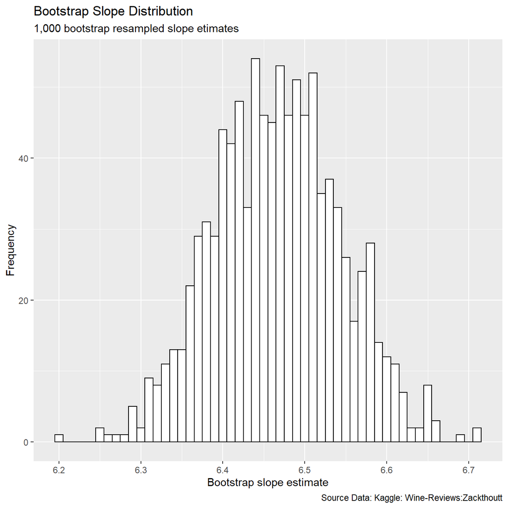

```
## # A tibble: 1 x 2
##   lower upper
##   <dbl> <dbl>
## 1  6.28  6.66
```

**Figure 3.2**

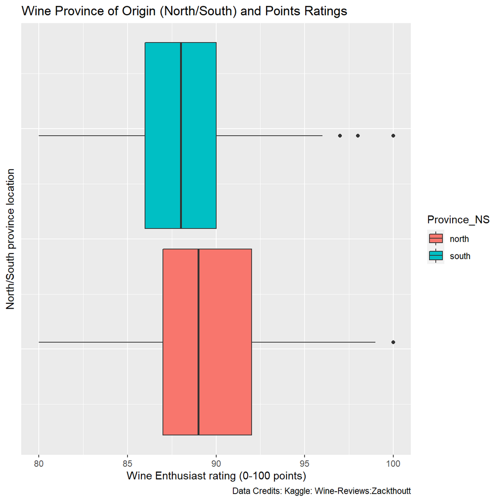

**Figure 3.3**

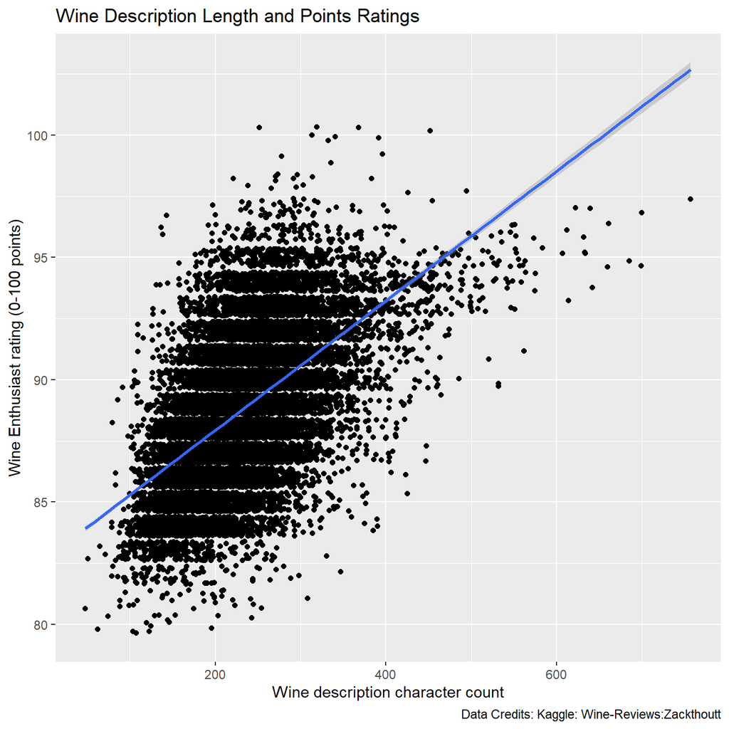

**Figure 3.4**

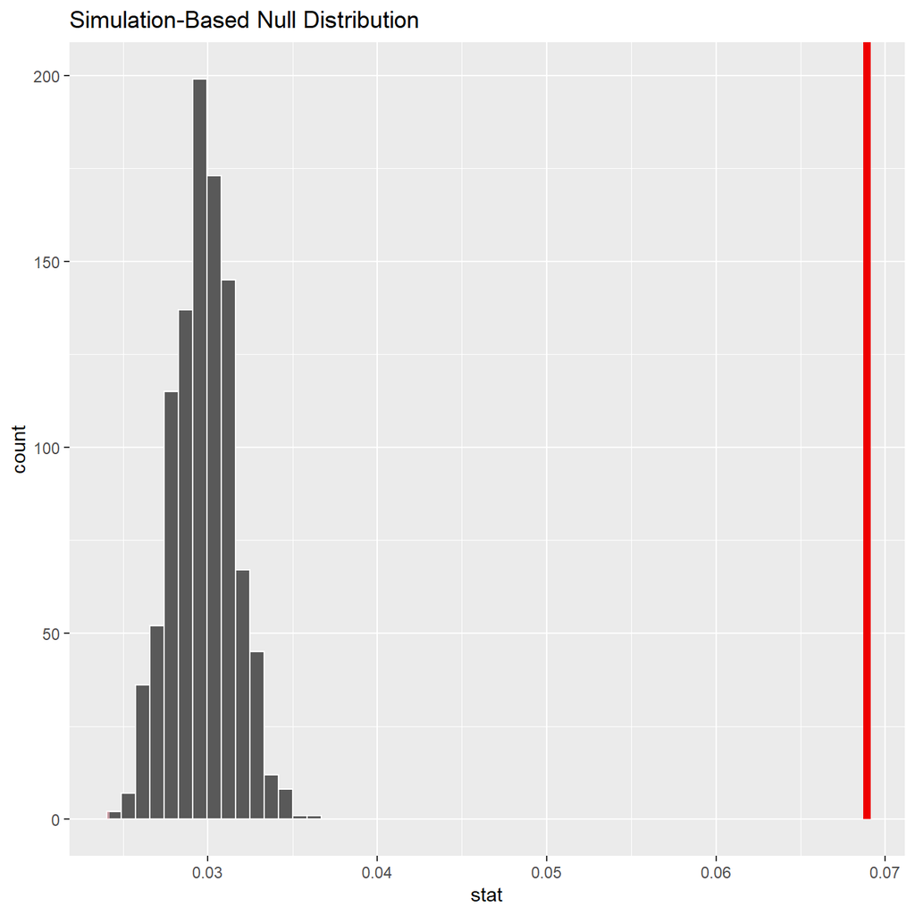

```
## # A tibble: 1 x 1
##   p_value
##     <dbl>
## 1       0
```

### Model Results

[output not shown]

## Section 3 - Results

**Model 3 (proposed by Max):**
$$\hat{points} = 77.1 + 5.17 * log\_price + 0.0182 * desc\_char\_count - 0.115 * province\_NSsouth$$

After developing three separate linear regression models for data prediction, we have determined model 3 to be the best fitting model for two primary reasons. The first is that it has the highest r squared and adjusted r squared values at 0.597 for both, which correspond to the percentage of the variance in the data explained by the variables in the model. The second is that it has the lowest RMSE values at 1.94 meaning that the model predicts points rating with an average accuracy of within 1.94 points. With the points variable having a full range of 20 values in the data set, this predicts well. Since this model has the lower number, and higher r squared we argue that this model is well enough to predict the response variable which is points, or wine ratings resulted from Wine Enthusiast.

```
## # A tibble: 4 x 2
##   term             estimate
##   <chr>               <dbl>
## 1 (Intercept)       77.1
## 2 log_price          5.17
## 3 desc_char_count    0.0179
## 4 province_NSsouth  -0.0497
```

```
## # A tibble: 1 x 2
##   r.squared adj.r.squared
##       <dbl>         <dbl>
## 1     0.587         0.587
```

```
## * NA -> ...1
```

```
##    prediction points
## 1    86.45743     87
## 2    87.40260     87
## 3    87.97950     87
## 4    83.50698     86
## 5    86.36199     86
## 6    86.28401     85
## 7    89.17296     86
## 8    87.80098     86
## 9    85.88590     86
## 10   89.50157     86
```

```
## # A tibble: 1 x 3
##   .metric .estimator .estimate
##   <chr>   <chr>          <dbl>
## 1 rmse    standard        1.94
```

$$\hat{points} = 77.1 + 5.17 * log\_price + 0.0179 * desc\_char\_count - 0.0497 * province\_NSsouth$$

Overall, the model does a good job of predicting the points data. From the model we can make conclusions about how the variables can effect the wine review. One of the scientific questions raised by our group is how higher prices influence the ratings of a certain wine, and from model 3 we can conclude that price does have a strong positive correlation with points, although the wine is not necessarily better or higher quality than wine that has lower price. We can also conclude that description length can have an effect on wine review and so can the province it originated, though less so. There are lots of factors that effect wine review points ratings, without attempting to account for all of them, the selected model predicts accurately.

## Bibliography

Zackthoutt. (2017). Wine Reviews (Kaggle; version 4) [data set] https://www.kaggle.com/zynicide/wine-reviews

White, Roland D. “Brace yourself for booze-flation. Your holiday alcohol run is just the beginning.” Los Angeles Times, December 13th, 2021, https://www.latimes.com/business/story/2021-12-13/why-your-holiday-booze-costs-more-this-year-alcohol-inflation

Kavanagh, Don “The Inexorable Rise of Wine Prices” Wine-Searcher, June 7th, 2019, https://www.wine-searcher.com/m/2019/06/the-inexorable-rise-of-wine-prices

Svitil, Kathy “Wine Study Shows Price Influences Perception” Caltech, January 14th, 2008, https://www.caltech.edu/about/news/wine-study-shows-price-influences-perception-1374

Morais, Rodolfo “Fresh Wine Regions and History” Grapes and Grains, June 2nd, 2017, https://www.grapesandgrains.org/2017/06/french-wine-regions-and-history.html

Masterclass, “A Complete Guide to 13 Types of Wine”, July 21st, 2021 https://www.masterclass.com/articles/a-complete-guide-to-13-types-of-wine#all-about-red-wine